# Regression Models Course Project

Simon Cox

15 Feb 2020

## Executive Summary

This report investigates 2 items of interest using data provided by the mtcars dataset in R. The summary of findings for these is below:

**Item 1) Is an automatic or manual transmission better for MPG?**  
All analysis and modelling of the data indicates that a manual transmission is likely to be better for MPG.

**Item 2) Quantify the difference between manual and automatic transmissions.**  
When using a simple linear regression model, we can say with 95% confidence that a manual transmission will provide somewhere between 3.64 and 10.85 mpg improvement over an automatic transmission.

When using a multivariable regression model using transmission type, weight and quarter mile time as regressors we can say with 95% confidence that a manual transmission will provide an improvement of somewhere between 0.05 and 5.83 mpg over automatic transmissions.

## Investigations

The dataset used for this assignment (mtcars) describes the mpg for a number of different cars, each of which has a number of features including the type of transmission. The first step in answering this question is to perform a quick analysis of the relationship between mpg and transmission type (referenced as “am” in the dataset). A boxplot provides a useful view and is provided in Figure 1 of the Appendix. The boxplot on its own shows that there is a clear distinction between the mpg for the transmission types, with automatic transmission having lower mpg. However when we look at the datapoints overlaid on the boxplot we see that things aren’t necessarily as clear cut as this, with some manual transmissions performing worse than the median mpg for automatic transmissions.  
We might also look for the correlation between the mpg and the automatic and manual transmissions (note that the dataset assigns a value of 0 for automtic and 1 for manual). The correlation value is 0.5998 which shows that there is some correlation but by no means could it be considered to be statistically strong.

### Simple Linear Regression

Nevertheless we can use a simple linear regression to see if we can get a good model. Figure 2 in the appendix shows the resulting summary information for this regression. The coefficients and related 95% confidence intervals are shown below:

```r
simple_linear <- lm(mpg ~ am, data = mtcars)
coef(simple_linear); confint(simple_linear)
```

```
## (Intercept)          am
##   17.147368    7.244939
```

```
##                2.5 %   97.5 %
## (Intercept) 14.85062 19.44411
## am           3.64151 10.84837
```

This model is suggesting that automatic transmissions (i.e. where the “am” variable has a value of 0) will provide somewhere between **14.85 and 19.44 mpg** with 95% confidence, as provided by the intercept. Additionally, we can interpret the coefficient to mean that manual transmissions (i.e. where the “am” variable has a value of 1) will provide somewhere between **3.64 and 10.85 mpg** improvement over an automatic transmission, with 95% confidence.

Figure 3 in the appendix shows us the Q-Q plot that determines whether the residuals from this model are approximately normally distributed. We can see that the points are somewhat close to the diagonal line which indicates that they are fairly normal in their distribution which in turn indicates a reasonable model.

Finally we can take a look at the adjusted R-squared figure which can give an indication as to the goodness of fit. For the simple linear model the adjusted R-squared is **0.3385**, which indicates that perhaps the model could be improved.

### Multivariable Regression

Simple linear regression rather surprisingly gave us a reasonable model, although the adjusted R-squared figure suggests it can be improved. Indeed common sense would tell us that there are probably other variables at play when it comes to the mpg achieved for a particular model of car. Therefore we can look to other variables provided in the dataset to try and get a more comprehensive model that might tell us the impact of the transmission type if we keep the other variables constant.

The first step is to determine which variables to include in the model. We know that the inclusion of variables with a high degree of correlation can be detrimental to the model, therefore we can look at a paired plot to identify highly correlated variables. This is shown in Figure 4 of the Appendix.

Correlations with an absolute value of > 0.7 are considered significant. With this in mind we can see that there are 2 variables correlated to “am” - these are “drat” (rear axle ratio) and “gear” (number of forward gears). Therefore we will leave those 2 variables out of the model because we know that we need to include “am”.

Logic tells us that the most important factors to determine the mpg other than the transmission type will be weight, the 1/4 mile time, number of carburetors and engine shape, in that order. Therefore we will fit multiple models, incrementing the number of variables each time until all variables are used, and then run an ANOVA to determine if the addition of the variable is significant for the model. This can be seen in Figure 5 of the Appendix.

This shows us quite clearly that the 3rd model (including “am”, “wt” and “qsec” as regressors) is the appropriate model to choose. It is a significant improvement on the single linear regression model, with the residual sum of squares falling from 720 to 169. The details of this model are shown in Figure 6 in the Appendix, and the coefficients and related 95% confidence intervals are shown below:

```r
coef(ml3); confint(ml3)
```

```
## (Intercept)          am          wt        qsec
##    9.617781    2.935837   -3.916504    1.225886
```

```
##                   2.5 %    97.5 %
## (Intercept) -4.63829946 23.873860
## am           0.04573031  5.825944
## wt          -5.37333423 -2.459673
## qsec         0.63457320  1.817199
```

Finally we can take a look at the adjusted R-squared figure which can give an indication as to the goodness of fit. For the multivariable model the adjusted R-squared is **0.8336**, which indicates that the model is a good fit.

## Appendix

### Figure 1

Boxplot showing relationship between mpg and transmission type.

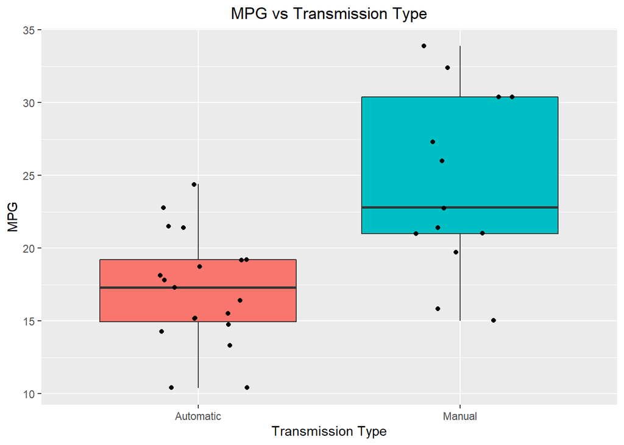

```r
Transmission <- rep.int("Automatic",dim(mtcars)[1])
Transmission[mtcars$am == 1] <- "Manual"
g <- ggplot(mtcars, aes(x = Transmission, y = mpg, fill = Transmission)) +
    geom_boxplot() +
    labs(title = "MPG vs Transmission Type", x = "Transmission Type", y = "MPG") +
    geom_jitter(shape=16,position=position_jitter(0.2)) +
    theme(legend.position = "none") +
    theme(plot.title = element_text(hjust = 0.5))
print(g)
```

### Figure 2

Summary of simple linear regression between mpg and transmission type.

```r
sl_sum <- summary(simple_linear)
print(sl_sum)
```

```
##
## Call:
## lm(formula = mpg ~ am, data = mtcars)
##
## Residuals:
##     Min      1Q  Median      3Q     Max
## -9.3923 -3.0923 -0.2974  3.2439  9.5077
##
## Coefficients:
##             Estimate Std. Error t value Pr(>|t|)
## (Intercept)   17.147      1.125  15.247 1.13e-15 ***
## am             7.245      1.764   4.106 0.000285 ***
## ---
## Signif. codes:  0 '***' 0.001 '**' 0.01 '*' 0.05 '.' 0.1 ' ' 1
##
## Residual standard error: 4.902 on 30 degrees of freedom
## Multiple R-squared:  0.3598, Adjusted R-squared:  0.3385
## F-statistic: 16.86 on 1 and 30 DF,  p-value: 0.000285
```

### Figure 3

Q-Q plot of residuals from simple linear regression between mpg and transmission type.

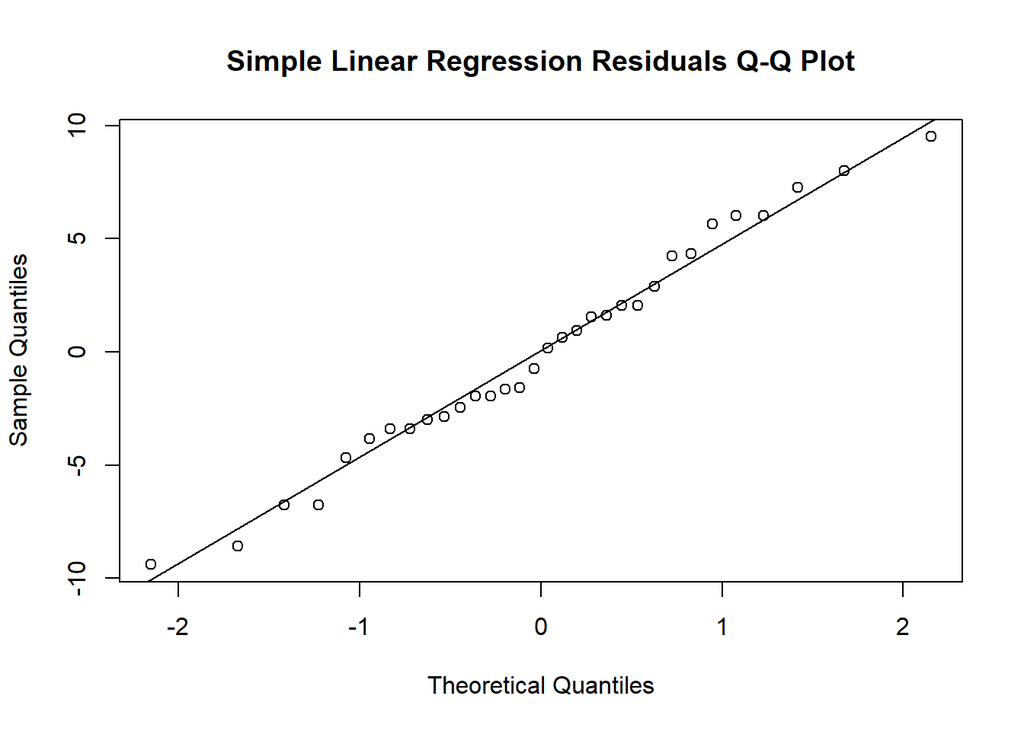

```r
sl_sum <- summary(simple_linear)
qqnorm(sl_sum$residuals, main="Simple Linear Regression Residuals Q-Q Plot")
qqline(sl_sum$residuals)
```

### Figure 4

Pairs Plot of all variables in mtcars dataset.

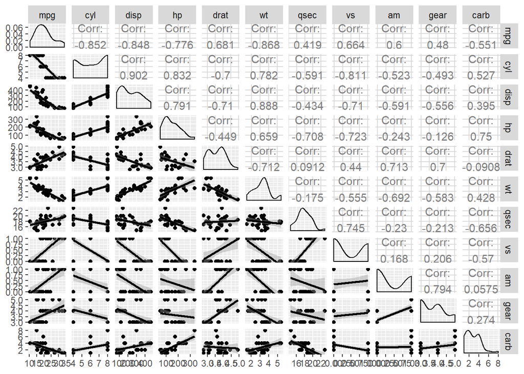

```r
g <- ggpairs(mtcars,lower = list(continuous = "smooth"))
print(g)
```

### Figure 5

Analysis of Variance (ANOVA) for multiple multivariable models.

```r
mult_linear_1 <- lm(mpg ~ am, data = mtcars)
mult_linear_2 <- lm(mpg ~ am + wt, data = mtcars)
mult_linear_3 <- lm(mpg ~ am + wt + qsec, data = mtcars)
mult_linear_4 <- lm(mpg ~ am + wt + qsec + carb, data = mtcars)
mult_linear_5 <- lm(mpg ~ am + wt + qsec + carb + vs, data = mtcars)
anova(mult_linear_1, mult_linear_2, mult_linear_3, mult_linear_4, mult_linear_5)
```

```
## Analysis of Variance Table
##
## Model 1: mpg ~ am
## Model 2: mpg ~ am + wt
## Model 3: mpg ~ am + wt + qsec
## Model 4: mpg ~ am + wt + qsec + carb
## Model 5: mpg ~ am + wt + qsec + carb + vs
##   Res.Df    RSS Df Sum of Sq       F    Pr(>F)
## 1     30 720.90
## 2     29 278.32  1    442.58 71.4358 6.216e-09 ***
## 3     28 169.29  1    109.03 17.5990 0.0002806 ***
## 4     27 161.25  1      8.04  1.2971 0.2651340
## 5     26 161.08  1      0.17  0.0272 0.8703959
## ---
## Signif. codes:  0 '***' 0.001 '**' 0.01 '*' 0.05 '.' 0.1 ' ' 1
```

### Figure 6

Summary of selected multivariable regression model.

```r
summary(mult_linear_3)
```

```
##
## Call:
## lm(formula = mpg ~ am + wt + qsec, data = mtcars)
##
## Residuals:
##     Min      1Q  Median      3Q     Max
## -3.4811 -1.5555 -0.7257  1.4110  4.6610
##
## Coefficients:
##             Estimate Std. Error t value Pr(>|t|)
## (Intercept)   9.6178     6.9596   1.382 0.177915
## am            2.9358     1.4109   2.081 0.046716 *
## wt           -3.9165     0.7112  -5.507 6.95e-06 ***
## qsec          1.2259     0.2887   4.247 0.000216 ***
## ---
## Signif. codes:  0 '***' 0.001 '**' 0.01 '*' 0.05 '.' 0.1 ' ' 1
##
## Residual standard error: 2.459 on 28 degrees of freedom
## Multiple R-squared:  0.8497, Adjusted R-squared:  0.8336
## F-statistic: 52.75 on 3 and 28 DF,  p-value: 1.21e-11
```

### Figure 7

Plots of residuals from multivariable linear regression.

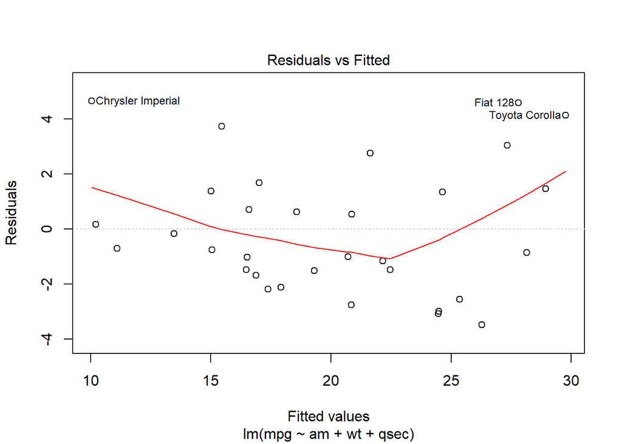

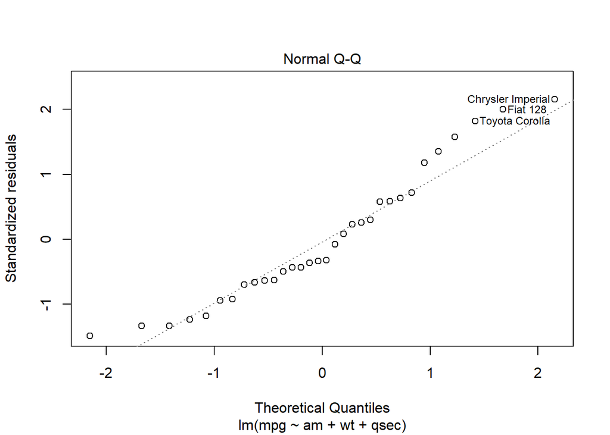

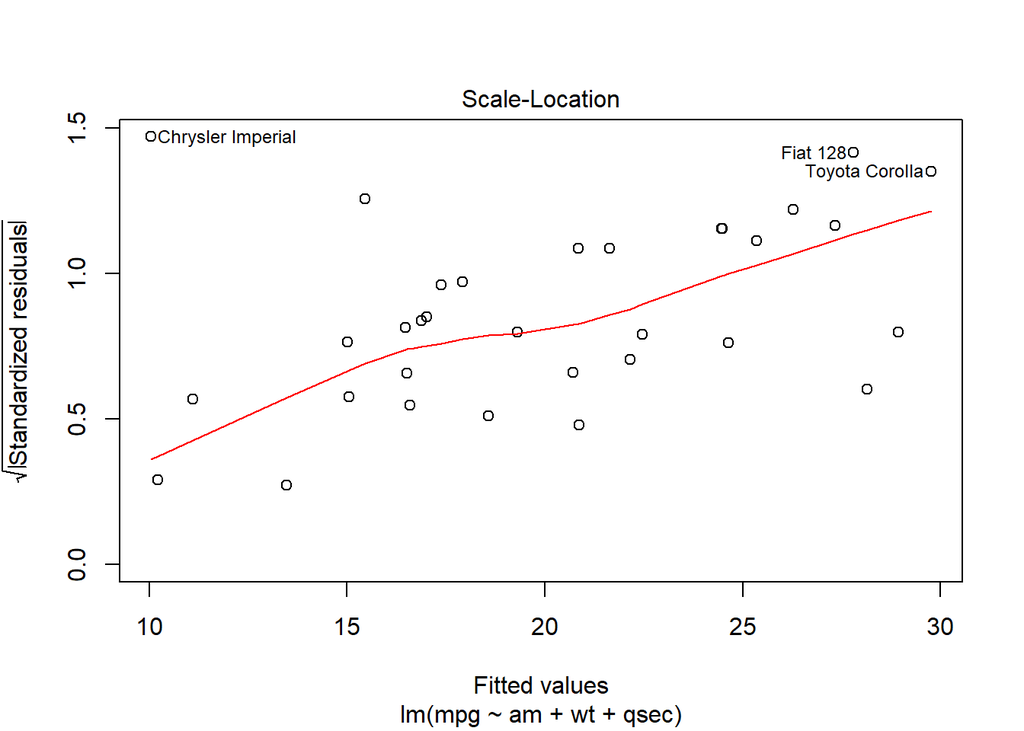

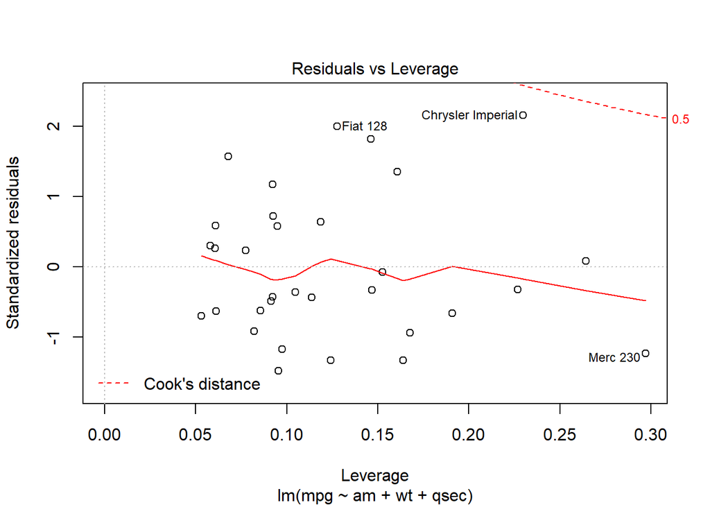

```r
plot(mult_linear_3)
```